# Generalizing regularized estimating equations for model selection to multiple clustered spatial point processes

Xiaokang Liu[^1]

12 December 2018

Abstract

This project aims to generalize the method introduced in Thurman et al. (2015), which focus on one single clustered point process variable selection problem, to solve several clustered spatial point processes simultaneously and then conduct variable selection by group Lasso.

# 1 Introduction

The distribution pattern of one certain tree species in a forest can be modeled as a clustered spatial point process. There is a variety of factors which may affect the spatial distribution of trees, including the elevation, slope and concentration of minerals at the place where a tree stands. In the realm of point process, the first order property describes the distribution pattern of points, and it can be well characterized by intensity function. When we want to incorporate the influences from some geographical factors into the model, we can specify the intensity function as a log-linear function of the factors of interest. Furthermore, based on this log-linear form, it is possible to conduct variable selection to simplify the model and distinguish some crucial factors from some nuisance covariates. Thurman et al. (2015) proposed a method to achieve this goal by adding a penalty on the model complexity to the goodness-of-fit part to impose sparsity on the model, thus facilitate variable selection. In their paper, three forms of penalties are applied to the model and all of them are designed to select variables for a single process but not for a group of them. In this project, we generalize the model of Thurman et. al (2015) to describe several clustered spatial point process simultaneously and select variables by exploiting information from all processes. Specifically, we model several clustered spatial point processes simultaneously based on the same set of factors, and then borrow strength from each process to get a small collection of variables that are influential to most of the processes. The model is established on the basis of independence between clustered spatial point processes condition on the predictors. The estimation and inference of the model are extentions from Thurman’s paper, and it can be shown that we can write the model in a form of group lasso and solve it efficiently. Simulation studies are conducted to verify the power of variable selection of our model. In addition, we apply our model to the Barro Colorado Island data. We categorize different species of trees into several groups based on their genus. Then, for each genus we apply our method to find out the factors that are important to the growth of this kind of trees. Finally, we compare the located factors of different genus of trees to obtain the information that if different genus of trees have different flavor to its surrounding enviromental factors.

The rest of this project is organized as follows: In Section 2 we introduce the model used to characterize the clustered spatial point process. In Section 3, we present details about model simplification and estimation. Next, a simulation study is conducted to investigate the variable selection performance of the method in Section 4. The application of the method to the Barro Colorado Island data is displayed in Section 5. Finally, we include some interesting further investigation direction in Section 6.

# 2 Model Formulation

## 2.1 Spatial point process

Let $(\Omega,\mathcal{A},P)$ denote a probability space and $D$ is a spatial domain of interest. Let $Y$ denote a mapping from $(\Omega, \mathcal{A}, P)$ to $N_D$, where $N_D$ is a set of realizations $y$ of $Y$ and satisfy $y \cap A$ is a finite set of spatial points in $D$ for any bounded Borel set $A \in D$. Then the mapping $Y$ is said to be a spatial point process on $D$ (Gaetan and Guyon (2010)). For a point process $Y$, we can use the intensity function $\lambda_Y$ to illustrate its spatial distribution. One fundamental example of spatial point process is the spatial Poisson process where we assume each event in this process is independent to each other. However, instead of assuming statistical independence among events in a process, it’s more realistic to consider a model which allows existence of dependence among points, for example, the spatial point pattern data with clusters. One popular class of models for clustered spatial point process are the Cox processes (Moller and Waagepetersen (2004)). In this project, we will focus on one example of Cox process, the Neyman-Scott process.

## 2.2 Neyman-Scott Process

Suppose we have a homogeneous Poission Process $C$ which has a constant intensity function $\kappa>0$, and let it be the parent process. Then given one event $c \in C$ from the parent process, we have a child process $Y_c$, which is a Poisson process with inhomogeneous intensity function $\lambda_c(s;\beta,w)=h(s-c;w)\exp\{x(s)'\beta\}$, where $w$ is a parameter of the child process, $x(s)\in R^{p+1}$ is a vector of geographical features at position $s$, and $\beta=(\beta_0,\ldots,\beta_p)\in R^{p+1}$ is the corresponding coefficients vector. Then the Neyman-Scott process can be represented as $Y=\cup_{c\in C}Y_c$ with intensity function $\lambda(s;\beta)=\kappa \exp\{x(s)'\beta\}$. Not like the Poisson process, the Neyman-Scott process can take into account the possible dependence between events, which is more realistic when we deal with practical problems. For example, when we model the distribution pattern of one species of trees, attraction or repulsion effect may exist among trees that stand in a neighborhood. Then it is not appropriate to use a Poisson process. One classical example of Neyman-Scott process is the Thomas process which denotes
$$h(s-c,w)=\frac{1}{2\pi w^2}\exp\{-\frac{\|s-c\|_2^2}{2w^2}\},$$
where both $s$ and $c$ are locations. In Thomas process, the interaction parameter pairs $\theta=(\kappa,w)$ controls the spatial interactions among events. A small $w$ leads to tighter clusters while a large $w$ corresponding to looser clusters. When $\kappa$ is small, there are fewer parent events and when $\kappa$ is large, we have more parent events. With a fixed total event number, a small $\kappa$ and a large $w$ lead to a small set of large and loose clusters. Similarly, we can use different combinations of these two parameters to adjust the distribution pattern of points.

The second order property of a spatial point process characterizes the neighborhood structure between events. There are two such functions to describe second order property, one is the reweighted pair correlation function of $Y$, which is defined as
$$g_Y(s_1,s_2)=\frac{\rho_Y(s_1,s_2)}{\lambda_Y(s_1)\lambda_Y(s_2)},$$
with $\rho_Y(s_1,s_2)$ is the second-order intensity density, and another one is the K-function of $Y$, which is the expected number of events to occur within distance $t$ of a given event, normalized by values of the intensity function. In the Thomas process, the K-function is
$$K(t;\theta)=\pi t^2 + \frac{1}{\kappa} [1-\exp\{-\frac{t^2}{4w^2}\}]$$
and the reweighted pair correlation function is
$$g(t)=1+\frac{1}{4\pi \kappa w^2}\exp\{-\frac{t^2}{4w^2}\}.$$

# 3 Model Estimation

Let $y_1,\ldots,y_n$ denote the observed spatial point pattern data of $Y$ in $D$. Note that $y_i$ here denotes position in $D$. Let’s first establish the likelihood function based on an inhomogeneous Poisson process, then we have
$$l(\beta)=\sum_{i=1}^n \log \lambda(y_i;\beta)-\int_D \lambda(s;\beta)ds,$$
and its first order derivative with respect to $\beta$ is
$$u(\beta)=\sum_{i=1}^n x(y_i)-\int_D x(s)\lambda(s;\beta)ds.$$
One way to obtain the estimates of $\beta$ is to solve $u(\beta)=0$, and it’s also verified that $u(\beta)=0$ is an unbiased estimating equation for $\beta$ in a Cox process. For improving computation efficiency, we focus on solving estimating equations to obtain estimates of $\beta$ in this project. Denote the estimates of $\beta$ from $u(\beta)=0$ as $\widetilde \beta^{EE}$. However, as this model is based on the Poisson process which ignores the possible dependence among events, for regaining the efficiency, we consider the following weighted estimating equation (Guan and Shen (2010))
$$u(\beta,w)=\sum_{i=1}^n w(y_i)x(y_i)-\int_D w(s)x(s)\lambda(s;\beta)ds=0,$$
which can be viewed as the first order derivative with respect to $\beta$ of a weighted quasi-log-likelihood
$$l_w(\beta)=\sum_{i=1}^n w(y_i)\log \lambda(y_i;\beta) - \int_D w(s)\lambda(s;\beta)ds.$$
We denote $\widetilde \beta^{WEE}$ as the solution of $u(\beta,w)=0$.

Next, we use quadrature approximation of the integral part in likelihood functions to help solve $\beta$. At first, let’s divide the domain of interest into a grid of rectangular pixels of number $M$, and let their centroids as dummy points. Thus, we have $M$ dummy points apart from the sample points to help approximate the integral. For each pixel, it has a common area $a$. Then we can write the approximation form of the unweighted likelihood function as
$$l(\beta)=\sum_{i=1}^n \log \lambda(y_i,\beta)-\sum_{i=1}^{n+M} v_i \lambda(s_i,\beta),$$
where $v_i=a/n_i$ and $n_i$ is the total number of sample points and dummy points in the pixel $i$. And similarly we have a weighted form
$$l_w(\beta)=\sum_{i=1}^n w_i \log \lambda(y_i,\beta)-\sum_{i=1}^{n+M} w_i v_i \lambda(s_i,\beta).$$
The performance of the quadrature approximation depends on $a$, when we have a finer devision the approximation will be better. Since these two approximation representations are similar to log-likelihood function for a weighted Poisson generalized linear model, we can solve them by using the a function ‘glm’ in R.

Till now, we’ve finished constructing the objection function to measure goodness-of-fit of the model. Next, we’re going to add a penalty on the model complexity to help conduct variable selection. In Thurman’s paper, they use adaptive lasso penalty $\sum_{i=1}^p \gamma_i |\beta_i|,\ \gamma_i>0$ to conduct model selection and get the following two objective functions
$$l_{pw}(\beta)=-l_w(\beta)+n\sum_{i=1}^p \gamma_i |\beta_i|$$
and
$$l_{p}(\beta)=-l(\beta)+n\sum_{i=1}^p \gamma_i |\beta_i|.$$
Let’s denote the solutions for them to be $\widehat \beta^{WEE}$ and $\widehat \beta^{EE}$, respectively.

Take the weighted model as an illustration, in specific, they first use a Laplace approximation of $l_w(\beta)$ as
$$l_w^*(\beta)=(\beta-\widehat \beta^{(m-1)})\frac{\partial l_w(\widehat\beta^{(m-1)})}{\partial \beta}+\frac{1}{2}(\beta-\widehat \beta^{(m-1)})'\frac{\partial^2 l_w(\widehat\beta^{(m-1)})}{\partial \beta \partial \beta'}(\beta-\widehat \beta^{(m-1)}),$$
where $\widehat \beta^{(m-1)}$ is the minimizer of $l_{pw}(\beta)$ at the $(m-1)$-th step. Then rearrange $l^*_w(\beta)$ by writting
$$\begin{align*}
A'A &= -\frac{\partial^2 l_w(\widehat\beta^{(m-1)})}{\partial \beta \partial \beta'} \\
Y^* &= (A^{-1})'\left\{\frac{\partial l_w(\widehat\beta^{(m-1)})}{\partial \beta}-\frac{\partial^2 l_w(\widehat\beta^{(m-1)})}{\partial \beta \partial \beta'}\widehat \beta^{(m-1)} \right\} \\
X^* &= A diag(\gamma_i^{-1}) \\
\beta^* &= (\gamma_1 \beta_1, \ldots, \gamma_p \beta_p)'.
\end{align*}$$
Then we have
$$l^*_w(\beta)=l^*_w(\beta^*)=-\frac{1}{2}\|Y^*-X^*\beta^*\|_2^2$$
and
$$l_{pw}(\beta)=\frac{1}{2}\|Y^*-X^*\beta^*\|_2^2+n\|\beta^*\|_1,$$
which is exactly the form of a Lasso regression. As for the selection of $\gamma_i$, following Zou (2006) we can set $\gamma_i=\gamma \log(n)(n|\widetilde \beta_{i}^{WEE}|)^{-1},\ i=1,\ldots,p$.

## 3.1 Model several clustered point processes together

Then, let’s consider a multi-task setting. Suppose we want to model $q$ many clustered spatial point processes $Y_1,\ldots,Y_q$ simultaneously on the same set of covariates $x_1(s),\ldots,x_p(s)$. Moreover, let’s further assume these $q$ processes are independent when given covariates. So the log-likelihood function for $Y_1,\ldots,Y_q$ given $x_1(s),\ldots,x_p(s)$ based on Poisson process can be written as
$$l(\beta^1,\ldots,\beta^q;Y_1,\ldots,Y_q)=l(\beta^1)+\ldots+l(\beta^q),$$
with
$$l(\beta^j)=\sum_{i=1}^{n_j}\log \lambda(y_{ji};\beta^j)-\int_D \lambda(s;\beta^j)ds,\ j=1,\ldots,q.$$
Then following the same procedure, we obtain
$$l^*_w(\beta^j)=l^*_w(\beta^{j*})=-\frac{1}{2}\|Y_j^*-X_j^*\beta^{j*}\|_2^2$$
for each process. That is to say, for each process, we can obtain $Y_j^*,A_j,X_j^*,\beta_j^*$ and $\{\gamma_{ji}\}'s$. Then we can get the following formulation
$$\begin{bmatrix}
Y_{1}^* \\
Y_{2}^* \\
\vdots \\
Y_{q}^*
\end{bmatrix}
=
\begin{bmatrix}
X_1^* & & \\
& \ddots & \\
& & X_p^*
\end{bmatrix}
\begin{bmatrix}
\beta^{1*} \\
\beta^{2*} \\
\vdots \\
\beta^{q*}
\end{bmatrix}$$
where $\beta^{j*}=(\beta^{j*}_1,\ldots,\beta^{j*}_p)$. Since all processes share the same set of covariates, we know that in each $\beta^{j*}$, there is one element corresponding to the same covariate. When it aims to find out the covariates that are influential to most of the processes, we can change the penalty to a group penelty form. That is, collect all items in $\beta^{1*},\ldots,\beta^{q*}$ that are corresponding to the same covariate to one group, which leads to $p$ groups in our case. Then we add penalty on each group as a whole to conduct variable selection for all processes simultaneously. This procedure can borrow strength from each process to decide the covariates that we want to keep. We can just use the sum of the $\ell_2$-norm on each group as a penalty. The resulting model is just the group lasso problem. Another thing that is different from Thurman’s method is that, we have to adjust adaptive weights $\gamma_{ij}$’s. There are two modifications we can apply, one is by simply setting all $\gamma_{ij}=1$, or we can further construct a new set of weights $g_i=\sqrt{\sum_{j=1}^q \gamma_{ij}^2}$ based on $\gamma_{ij}$ as Zou (2005) and let the group Lasso penalty to be
$$n\gamma \sum_{i=1}^p g_i \sqrt{\sum_{j=1}^q (\beta_i^{j})^2}.$$

## 3.2 Selection of weight function

Then let’s look into the weights $w(s)$:
$$w(s)=\frac{1}{1+\lambda(s)f(s)},\ f(s)=\int_D [g(u-s)-1]du.$$
If the process $Y$ is $m$-dependent, i.e., $g(u-s)=1 \ \text{when} \ \|u-s\|>m$, then we have
$$f(s)=K(m)-\pi m^2, \forall s.$$
Here we have the corresponding estimates
$$\widehat K(m)=\sum_{y_1,y_2 \in Y\cap D} \frac{I(0\leq\|y_1-y_2\|\leq m)}{\exp\{x(y_1)'\widetilde \beta^{EE}\}\exp\{x(y_2)'\widetilde \beta^{EE}\}}e_{y_1,y_2}$$
and
$$\widehat \lambda(s)=\lambda(s;\widetilde \beta^{EE}).$$
So we have
$$\widehat w(s)=[1+\widehat \lambda(s)\widehat f(s)]^{-1}.$$

The general procedure to conduct estimation is as follows: based on the log-likelihood function, we use a quadrature approximation to approximate the integral part and then use ‘glm’ to solve for $\widetilde \beta^{EE}$. By using $\widetilde \beta^{EE}$, we get the value of weights and then follow the similar way to get $\widetilde \beta^{WEE}$. For several point process, we do the same thing to get $\widetilde \beta^{WEE}$ for each of them, and then use $\widetilde \beta^{WEE}$ as the initial value to fit the group Lasso model. Since in each iteration the selected variables may be different, so we have to update weights $w(s)$ at each iteration, then also adjust the group Lasso problem and get a new set of coefficients. This procedure will continue until some sort of convergence of coefficients is obtained. Moreover, the coefficient corresponding to the intercept in each process will remain unpenalized. For simplicity, in this paper we will only conduct the whole procedure once without iteration, and keep the results as the final estimates.

# 4 Simulation Study

The simulation study has a setup similar to Waagepetersen (2007) and Thurman (2015). The spatial domain is $D=[0,1000]\times[0,500]$. From the R package ‘spatstat’, we get and standardize the elevation and slope data from the dataset ‘bei’ to be two covariates $z_{14}$ and $z_{15}$. Also, we generate thirteen covariates $z_j$ from standard normal as noise covariates, and all of them are standardized before fitting into the model. Then we add some multicollinearity among covariates into the data. That is, we define $\Sigma=V'V$ and $\Sigma[i,j]=\Sigma[j,i])=0.5^{|i-j|},i,j=1,\ldots,15$, except $\Sigma[14,15]=\Sigma[15,14]=0$, and then we take $x(s)=V'z(s)$ as the covariates we used in simulation study. That is, $x_1(s),\ldots,x_{13}(s)$ are noise predictors, and $x_{14}(s)$ is the elevation at $s$, $x_{15}(s)$ is the slope at location $s$. We consider $q=5$ clustered point processes here. All processes share the same devision of $D$ to conduct quadrature approximation. For each one of them, the coefficients are generated in a similar pattern but with little variation. Moreover, for investigating the performance of the proposed method from different aspects, we set up several situations to do simulation.

- case 1: one of the noise predictors, $x_{13}(s)$ has non-zero coefficient, and slope has non-zero coefficient, and the remaining covariates have no impact on the process, i.e, $\beta_{15,1}=1.0,\ \beta_{15,2}=1.1,\ \beta_{15,3}=1.9, \ \beta_{15,4}=1.5, \ \beta_{15,5}=1.7$ and $\beta_{13,1}=1.30,\ \beta_{13,2}=1.20,\ \beta_{13,3}=1.20, \ \beta_{13,4}=1.60, \ \beta_{13,5}=1.51$.
- case 2: one of the noise predictors, $x_{13}(s)$ has non-zero coefficient, and elevation has non-zero coefficient, and the remaining covariates have no impact on the process, i.e, $\beta_{14,1}=1.0,\ \beta_{14,2}=1.1,\ \beta_{14,3}=1.9, \ \beta_{14,4}=1.5, \ \beta_{14,5}=1.7$ and $\beta_{13,1}=1.30,\ \beta_{13,2}=1.20,\ \beta_{13,3}=1.20, \ \beta_{13,4}=1.60, \ \beta_{13,5}=1.51$.
- case 3: two noise predictors, $x_{1}(s)$ and $x_{10}(s)$ have non-zero coefficients, and the remaining covariates have no impact on the process, i.e, $\beta_{1,1}=1.0,\ \beta_{1,2}=1.1,\ \beta_{1,3}=1.9, \ \beta_{1,4}=1.5, \ \beta_{1,5}=1.7$ and $\beta_{10,1}=1.30,\ \beta_{10,2}=1.20,\ \beta_{10,3}=1.20, \ \beta_{10,4}=1.60, \ \beta_{10,5}=1.51$.
- case 4: Elevation has non-zero coefficient, and the remaining covariates have no impact on the process, i.e, $\beta_{14,1}=1.0,\ \beta_{14,2}=1.1,\ \beta_{14,3}=1.9, \ \beta_{14,4}=1.5, \ \beta_{14,5}=1.7$.
- case 5: Slope has non-zero coefficient, and the remaining covariates have no impact on the process, i.e, $\beta_{15,1}=1.0,\ \beta_{15,2}=1.1,\ \beta_{15,3}=1.9, \ \beta_{15,4}=1.5, \ \beta_{15,5}=1.7$.

Then we use function ‘rThomas’ in R package ‘spatstat’ to generate Thomas process under each setting. Some other parameters are $\kappa=5\times 10^{-5}$, $w=30$ and $m=10$. The estimation follows the method described before. For simplicity, we set all $\gamma_{ij}=1$. Also, since all groups have the same group size, we don’t have to add additional weights to get rid of the group size effect. Moreover, we fit the model with a path of tuning parameter $\gamma$ and summarized the results obtained by fixing $\gamma=0.147$, which is selected by empirical to make a large set of covariates to have coefficients zero. For each setting, the process is repeated 200 times. The results are summarized as histograms of squared $\ell_2$ norm of estimated coefficients in each group over 200 times repetition.

- case 1: The histogram of the squared $\ell_2$ norm of the estimated coefficient for slope centered at 2, which indicates that slope has significant effecct on the distribution intensity of the set of clustered point processes. Moreover, since the correlation between slope and elevation, some of the estimates of elevation coefficient are also significantly differ from 0. As for the noise predictor $x_{13}(s)$, its estimated coefficients are located around 1, which coincides with the model setting. For all the other covariates, their histograms share a similar pattern as $x_{10}(s),x_{11}(s),x_{12}(s)$ which shows that the magnitude of them are ignorable compared to $x_{13}(s),x_{14}(s),x_{15}(s)$, thus we didn’t include their plots in this section.

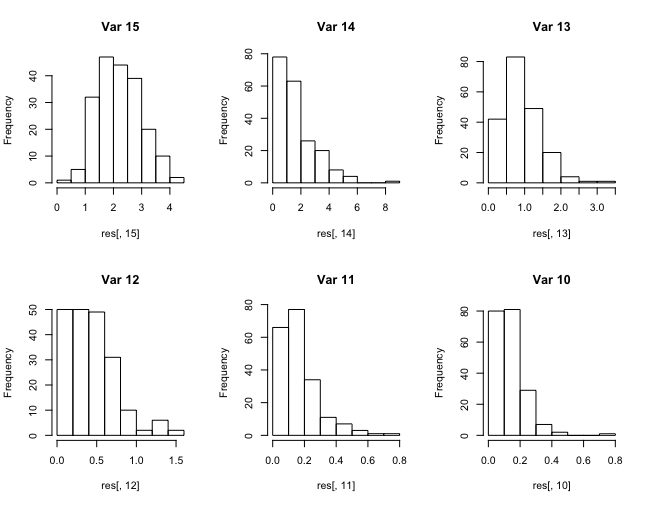

```r
knitr::include_graphics("Sim1.png")
```

- case 2: The characteristics of plots are similar to case 1.

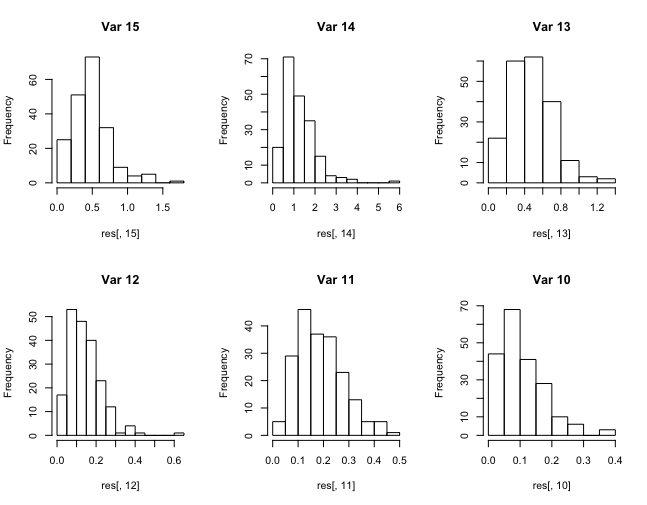

```r
knitr::include_graphics("Sim2.png")
```

- case 3: In this setting, two noise predictors $x_1(s)$ and $x_{10}(s)$ are assigned non-zero coefficients and all others are zero. From all the histograms, we can see that there is no strong signal among them, including $x_1(s)$ and $x_{10}(s)$. That is because the only two covariates related to non-zero coefficients are randomly generated from standard normal distribution, thus in any place of the whole domain the expected distribution intensity is the same, which leads to a homogeneous point process in the whole space. So, the proposed method cannot capture any siginificant factor under this situation.

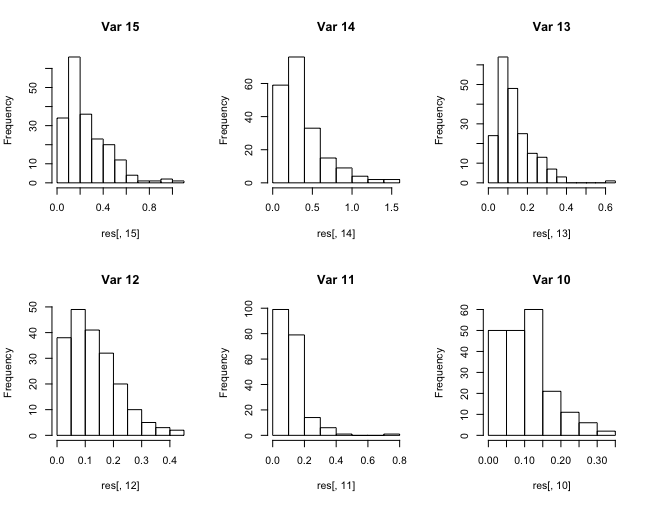

```r
knitr::include_graphics("Sim31.png")
```

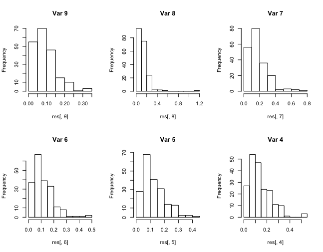

```r
knitr::include_graphics("Sim32.png")
```

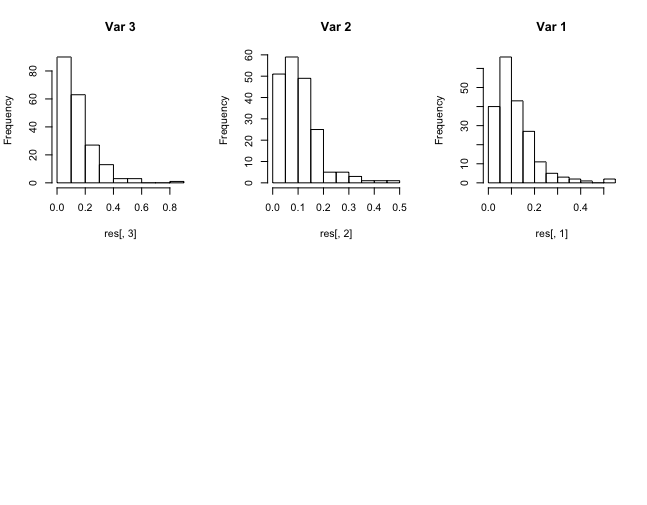

```r
knitr::include_graphics("Sim33.png")
```

- case 4: Here we let elevation be the only influential factor among all others. The histogram of elevation indicates that the magnitude of signal from elevation is the strongest. Also, due to correlation induced by the correlation matrix, estimates related to slope and $x_{13}(s)$ are significantly depart from 0. All the others have ignorable signal strength.

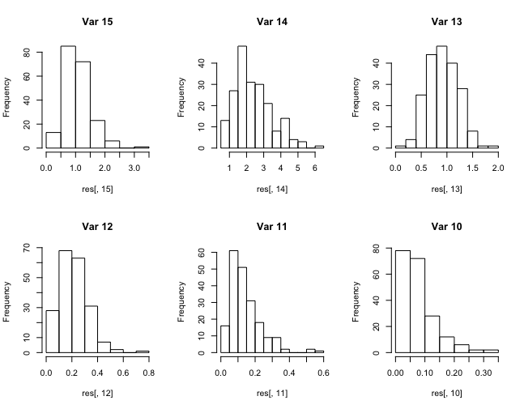

```r
knitr::include_graphics("Sim41.png")
```

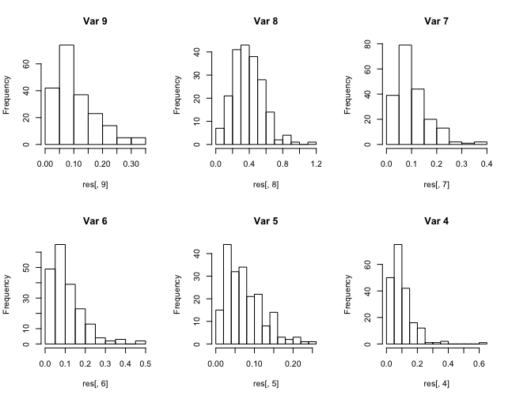

```r
knitr::include_graphics("Sim42.png")
```

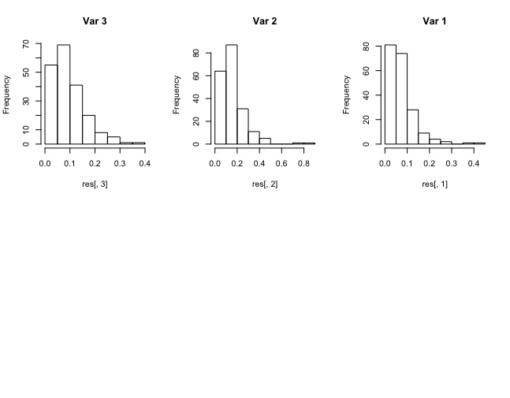

```r
knitr::include_graphics("Sim43.png")
```

- case 5: Here we let slope be the only influential factor among all others. Similar to the analysis in case 4, slope and elevation both have large enough magnitude to be selected by our method, and $x_{13}(s)$ has signal strength slightly larger than other noise covariates due to its correlation with slope and elevation.

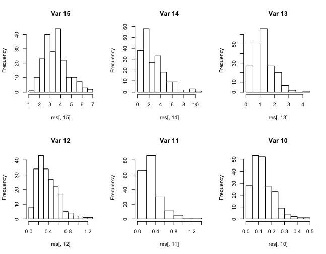

```r
knitr::include_graphics("Sim51.png")
```

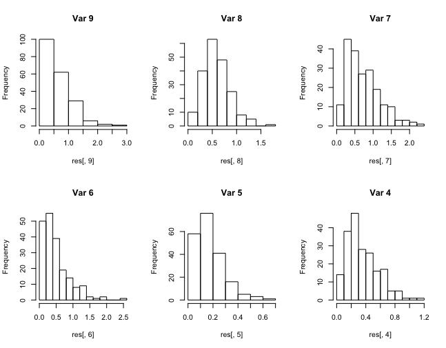

```r
knitr::include_graphics("Sim52.png")
```

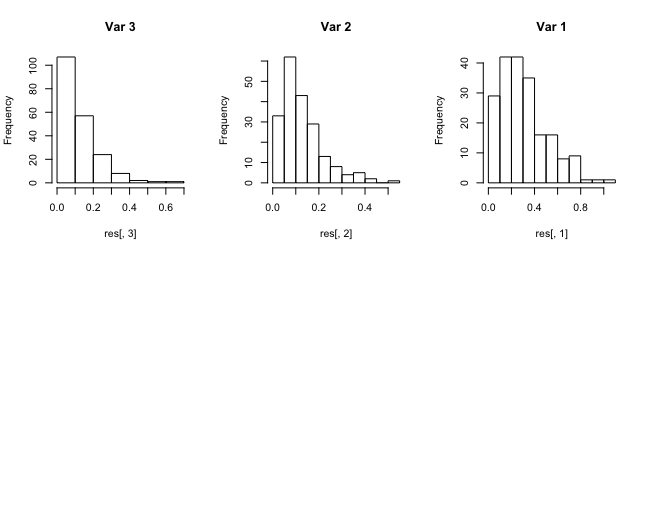

```r
knitr::include_graphics("Sim53.png")
```

# 5 Application

In this section, we apply our model to the Barro Colorado Island data. The domain of interest is a rectangular space $[0,1000] \times [0,500]$ with unit meter. Seven censuses of all the trees in this region has been conducted in the past years, the information obtained in these censuses including the location, height of the trees, also the species, genus or family that the tree belongs to. The considered genus of trees are (The format is like: Genus, species (mnemonic, number of trees)):

- Inga: acuminata(ingas1, 334), cocleensis(ingaco, 29), goldmanii(ingago, 154), laurina(ingafa, 27), marginata(ingama, 409), nobilis(ingaqu, 303), oerstediana(ingami, 2), pezizifera(ingape, 84), punctata(ingapu, 29), ruiziana(ingaru, 5), sapindoides(ingasa, 113), spectabilis(ingasp, 14), thibaudiana(ingath, 148), umbellifera(ingaum, 403).
- Ocotea: cernua(ocotce, 230), oblonga(ocotob, 144), puberula(ocotpu, 108), whitei(ocotwh, 203).
- Eugenia: coloradoensis(eugeco, 318), galalonensis(eugega, 1020), nesiotica(eugene, 306), oerstediana(eugeoe, 969).

Then, for each genus we apply our method to find out the factors that are important to the growth of this kind of trees. Finally, we compare the located factors of different genus of trees to obtain the information that if different genus of trees have different flavor to its surrounding enviromental factors. Take Inga as an example, we only use 7 species with the largest sample size to fit the model, and the plots for the squared $\ell_2$ norm of each group estimates along the solution path are

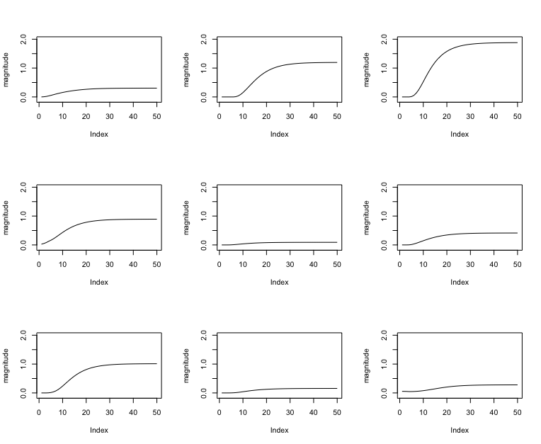

```r
knitr::include_graphics("Inga1.png")
```

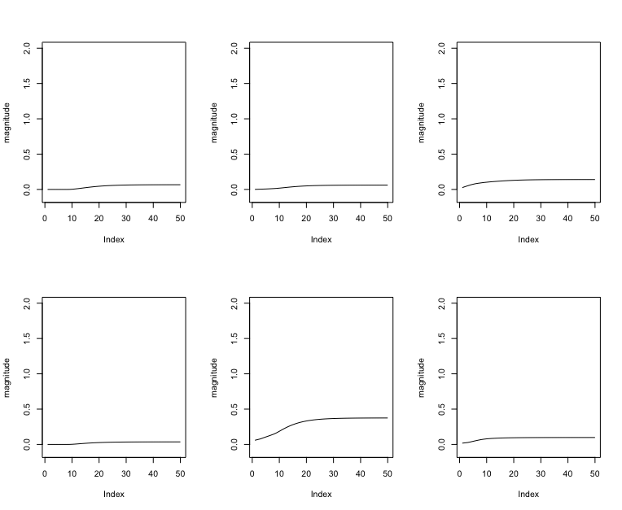

```r
knitr::include_graphics("Inga2.png")
```

Thus according to the strength observed from the plots, for Inga, the selected sets including: 1(Al),2(B),3(Ca),4(Cu),6(K),7(Mg) and elevation. Similarly, for the other two genus, we have that, for Eugenia, the selected sets including: 3(Ca),6(K),7(Mg) and elevation; for Ocotea, the selected sets including: 2(B),3(Ca),6(K),7(Mg), elevation and slope.

# 6 Discussion

In this project, we simply generalize the method introduced in Thurman (2015) into the one that can handle several clustered point process simulataneously and select variables by using group Lasso. This model can be used to specify the set of varibles that are influential to all the processes in a group by borrowing strength from each one of them. One drawback of our model is the assumption that given covariates all the processes considered are independent to each other. In some situations, there are also some impacts from one process to another, for example, two species of trees may compete for limited resources in one neighborhood. Thus, it is necessary to consider models that can take into consideration of dependence between several processes.

[^1]: xiaokang.liu@uconn.edu; Ph.D. student at Department of Statistics, University of Connecticut.